# Aplicação dos recursos existentes em R nas imagens PolSAR

John Victor, Alejandro Frery

Janeiro 19, 2018

### Introdução

Primeiramente, foram identificados três desafios ao se trabalhar com as imagens PolSAR na linguagem R que seriam a carência de metadados para a imagem, tendo em vista o processamento bruto e direto com os arquivos .slc, uma visualização dos dados com poucas informações e o enorme tamanho que essas imagens podem ter. Entretanto, a biblioteca raster oferece recursos para solucionar tais problemas e que serão apresentados mais adiante.

### Dado utilizado

O código abaixo carrega o dado que será utilizado nessa apresentação

```r
library(raster)
setwd("/home/john/New-R-Library/New-R-Library/Text/Reports/Fourth")
load("Uavsar.rdata")
```

### Metadados

O fato de estarmos obtendo a imagem diretamente do arquivo .slc faz com que seja necessário o processamento desses dados para acrescentar informações essenciais ao se trabalhar com imagens que possui dados geográficos. Além disso, foi visto que a comunidade normalmente utiliza diversos formatos de arquivos para representar melhor essas imagens, um exemplo comum é o formato GeoTIFF que contém metadados da imagem. Felizmente, a biblioteca raster oferece um tipo de objeto que pode armazenar atributos como extent, spatial reference e statical values (Mean value, min value…).

```r
# Obtenção das bandas da imagem e a transformação em raster layers
r1 <- raster(UavsarRGB_Eq[,,1])
r2 <- raster(UavsarRGB_Eq[,,2])
r3 <- raster(UavsarRGB_Eq[,,3])
# Apresentação dos principais metadados
r123 <- stack(r1, r2, r3)
```

### Visualização do dado

A falta de informações no raster layer ocasiona em uma visualização com poucas informações geográficas, mais abaixo teremos exemplos de plotagem dos dados, a primeira trata-se de uma visualização utilizada no meio acadêmico, a segunda é como encontra-se o nosso raster layers e a terceira é o que conseguimos fazer com poucas alterações no objeto raster.

**Visualização academica:**

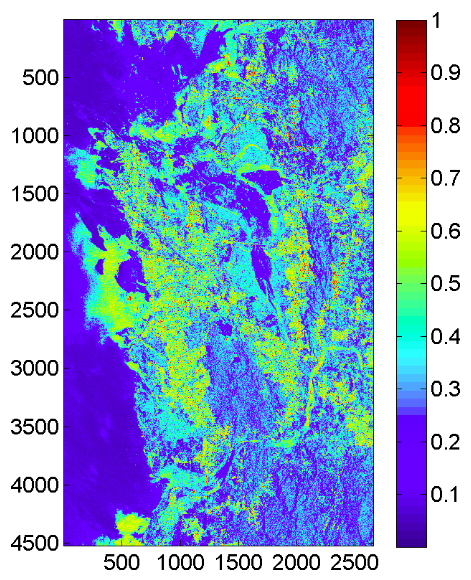

**Visualização sem tratamento:**

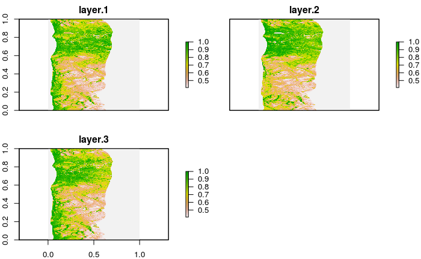

```r
plot(r123)
```

**Visualização com tratamento básico:**

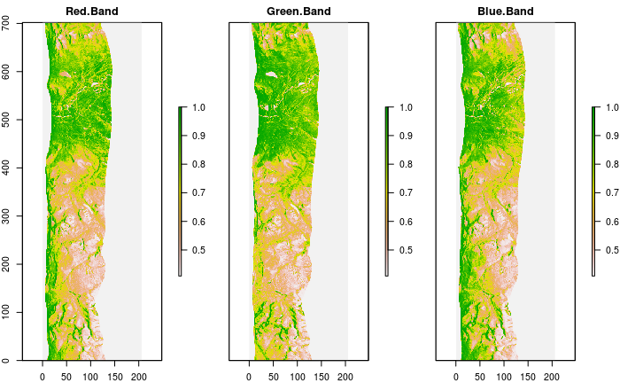

```r
ext <- extent(c(0, 206, 0, 702))
r123 <- setExtent(r123, ext)
names(r123) <- c("Red Band","Green Band","Blue Band")
crs(r123) <- "+proj=utm +zone=18 +datum=WGS84 +units=m +no_defs"
plot(r123, nc = 3, nr = 1)
```

```r
r123
```

```
class       : RasterStack
dimensions  : 702, 206, 144612, 3  (nrow, ncol, ncell, nlayers)
resolution  : 1, 1  (x, y)
extent      : 0, 206, 0, 702  (xmin, xmax, ymin, ymax)
coord. ref. : +proj=utm +zone=18 +datum=WGS84 +units=m +no_defs
names       :  Red.Band, Green.Band, Blue.Band
min values  : 0.4088665,  0.4088665, 0.4088665
max values  :         1,          1,         1
```